# Regression Analysis - STAT 482 - Probem Set 9

Alex Towell (atowell@siue.edu)

# Problem 1

> A router is used to cut locating notches on a circuit board. The vibration level is considered to be an important characteristic of the process. Two factors are thought to affect vibration ($y$): bit size ($x_1$) and cutting speed ($x_2$). The data is available as a csv file posted on Blackboard.

## Part (a)

> Provide a definition for an interaction effect.

The interaction effect measures the change in an input effect as the other input changes levels.

## Part (b)

> Fit an interaction model using coded variables. Compute the coefficient estimates and the standard error.

## Coded data transformation

```r
data = read.csv('hw9-1.csv')

to_binary_coded = function(x)
{
  2*(x-mean(x)) / (max(x)-min(x))
}
data$x1 = to_binary_coded(data$bit.size)
data$x2 = to_binary_coded(data$cutting.speed)
data$y = data$vibration
head(data)
```

```
##   bit.size cutting.speed vibration x1 x2    y
## 1   0.0625            40      18.2 -1 -1 18.2
## 2   0.1250            40      27.2  1 -1 27.2
## 3   0.0625            90      15.9 -1  1 15.9
## 4   0.1250            90      41.0  1  1 41.0
## 5   0.0625            40      18.9 -1 -1 18.9
## 6   0.1250            40      24.0  1 -1 24.0
```

# Estimates

```r
x.mod = lm(y ~ x1*x2,data=data) # equiv to y~x1+x2+x1:x2 and y~x1+x2+I(x1*x2)
summary(x.mod)
```

```
##
## Call:
## lm(formula = y ~ x1 * x2, data = data)
##
## Residuals:
##    Min     1Q Median     3Q    Max
## -3.975 -1.550 -0.200  1.256  3.625
##
## Coefficients:
##             Estimate Std. Error t value Pr(>|t|)
## (Intercept)  23.8312     0.6112  38.991 5.22e-14 ***
## x1            8.3188     0.6112  13.611 1.17e-08 ***
## x2            3.7687     0.6112   6.166 4.83e-05 ***
## x1:x2         4.3562     0.6112   7.127 1.20e-05 ***
## ---
## Signif. codes:  0 '***' 0.001 '**' 0.01 '*' 0.05 '.' 0.1 ' ' 1
##
## Residual standard error: 2.445 on 12 degrees of freedom
## Multiple R-squared:  0.9581, Adjusted R-squared:  0.9476
## F-statistic: 91.36 on 3 and 12 DF,  p-value: 1.569e-08
```

```r
coef(x.mod)
```

```
## (Intercept)          x1          x2       x1:x2
##    23.83125     8.31875     3.76875     4.35625
```

We see that
$$\hat{E}(Y|x) = 23.83 + 8.32 x_1 + 3.77 x_2 + 4.36 x_1 x_2.$$

## Part (c)

> Write the estimated regression as a function of $x_1$ for $x_2 = 1,0,-1$.

We have the regression function $\hat{E}(Y|x)$, so, for instance, $\hat{E}(Y|x_2=0) = 23.83 + 8.32 x_1 + 3.77 (0) + 4.36 (0) x_1 = 23.83+8.32 x_1$. However, in R, we may compute the slope and intercept estimates with:

```r
b0 = coef(x.mod)[1]
b1 = coef(x.mod)[2]
b2 = coef(x.mod)[3]
b12 = coef(x.mod)[4]
reg.estimates.x1 = matrix(c(b0+b2,b0,b0-b2,b1+b12,b1,b1-b12),nrow=3)
dimnames(reg.estimates.x1) = list(c("x2=+1","x2=0","x2=-1"),
                                  c("intercept","slope"))
reg.estimates.x1
```

```
##       intercept    slope
## x2=+1  27.60000 12.67500
## x2=0   23.83125  8.31875
## x2=-1  20.06250  3.96250
```

Thus,

$$\begin{align*}
\hat{E}(Y&|x_1,x_2=+1) = 27.600 + 12.675 x_1,\\
\hat{E}(Y&|x_1,x_2=0) = 23.831 + 8.319 x_1,\\
\hat{E}(Y&|x_1,x_2=-1) = 20.063 + 3.963 x_1.
\end{align*}$$

## Part (d)

> Create interaction plots for both the interaction model and the additive effects model.

Interaction plot of the interaction model:

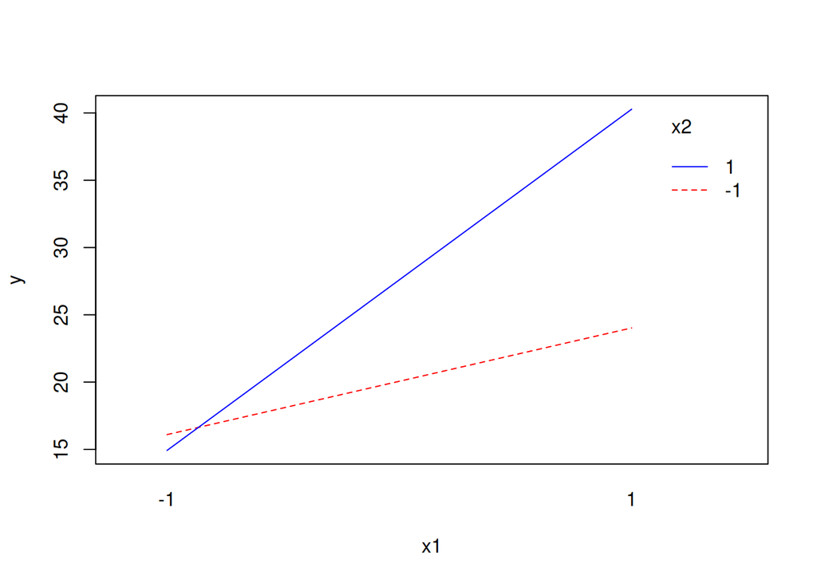

```r
x.pred = predict(x.mod)
# applying the plot to x1,x2,x.pred same as
# applying the plot to x1,x2,y.
interaction.plot(data$x1,data$x2,x.pred,
                 col=c("red","blue"),
                 trace.label="x2",
                 xlab="x1",
                 ylab="y")
```

Interaction plot of the additive model:

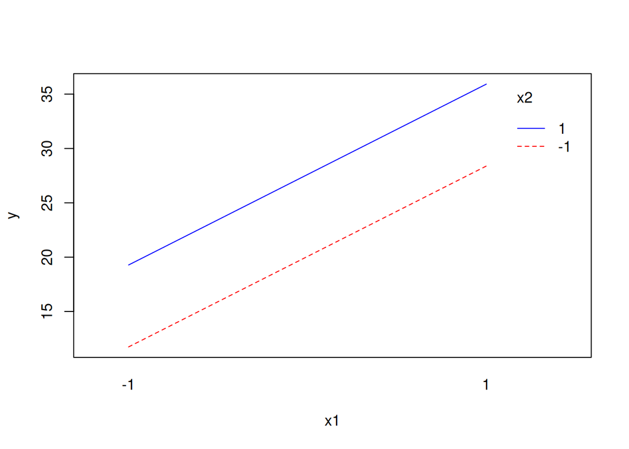

```r
add.mod = lm(y~x1+x2,data=data)
add.pred = predict(add.mod)
interaction.plot(data$x1,data$x2,add.pred,
                 col=c("red","blue"),
                 trace.label="x2",
                 xlab="x1",
                 ylab="y")
```

## Part (e)

> Test for an interaction effect. (Compute the test statistic and p-value.) Provide an interpretation, stated in the context of the problem.

```r
anova(add.mod,x.mod)
```

```
## Analysis of Variance Table
##
## Model 1: y ~ x1 + x2
## Model 2: y ~ x1 * x2
##   Res.Df    RSS Df Sum of Sq      F    Pr(>F)
## 1     13 375.35
## 2     12  71.72  1    303.63 50.801 1.201e-05 ***
## ---
## Signif. codes:  0 '***' 0.001 '**' 0.01 '*' 0.05 '.' 0.1 ' ' 1
```

$F^* \approx 50$ is quite large ($p = .000$). We find the data to be incompatible with the additive model.

# Problem 2

> A sample of healthy females is selected to investigate the relationship between age ($x$) and the level of a steroid ($y$). Refer to the data from Exercise 8.6.

## Part (a)

> Fit a quadratic model using coded variables. Compute $R^2$ for the quadratic model.

```r
data = read.table('CH08PR06.txt')
names(data) = c('y','x')
head(data)
```

```
##      y  x
## 1 27.1 23
## 2 22.1 19
## 3 21.9 25
## 4 10.7 12
## 5  1.4  8
## 6 18.8 12
```

```r
# poly uses coded variables (orthogonal)
#     => z1 = a1 + b1 x
#        z2 = a2 + b2 x + c2 x^2
quad.mod = lm(y ~ poly(x,2),data=data)
coef(quad.mod)
```

```
## (Intercept) poly(x, 2)1 poly(x, 2)2
##    17.64444    28.16524   -15.90551
```

```r
r2 = summary(quad.mod)$r.squared
r2
```

```
## [1] 0.8143372
```

The estimate for the quadratic regression model is
$$E(Y|x) = 17.644 + 28.165 x - 15.906 x^2,$$
for which
$$R^2 = 0.8143372.$$

## Part (b)

> Fit a cubic model using coded variables. Compute $R^2$ for the cubic model.

```r
cubic.mod = lm(y ~ poly(x,3),data=data)
coef(cubic.mod)
```

```
## (Intercept) poly(x, 3)1 poly(x, 3)2 poly(x, 3)3
##   17.644444   28.165236  -15.905513    4.086111
```

```r
r2 = summary(cubic.mod)$r.squared
```

The estimate for the cubic regression model is
$$E(Y|x) = 17.644 + 28.165 x - 15.906 x^2 + 4.086 x^3,$$
which, given the orthogonal design, has the same coefficients as previously for the lower-order terms.

As expected, $R^2$ has increased,
$$R^2 = 0.8273324,$$
but only slightly.

## Part (c)

> Create a scatterplot of the data, comparing the fitted values from the quadratic model with the fitted values from the cubic model. Extrapolate the predictions $10$ years beyond the largest age in the data set.

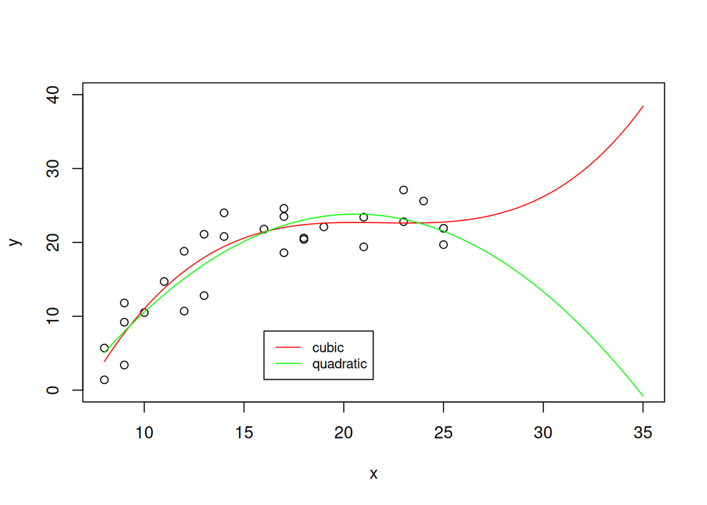

```r
newdat = data.frame(x=seq(min(data$x),max(data$x)+10,length.out=100))
newdat$cubic.pred = predict(cubic.mod, newdata = newdat)
newdat$quad.pred = predict(quad.mod, newdata = newdat)

plot(data$x,data$y,
     xlim=c(min(data$x),max(data$x)+10),
     ylim=c(0,40),
     xlab="x",
     ylab="y")
legend(16, 8, legend=c("cubic","quadratic"),
       col=c("red","green"), lty=1:1, cex=0.8)
points(newdat$x,newdat$cubic.pred,type="l",col="red")
points(newdat$x,newdat$quad.pred,type="l",col="green")
```

Informally, unless we have prior information (e.g., scientific insight), the simpler (quadradic) model seems like a more likely fit to the underlying data generating process.